# finance-database

[figure not shown]

The Finance Toolkit is complimented very well with the [Finance Database 🌎](https://github.com/JerBouma/FinanceDatabase), a database that features 300.000+ symbols containing Equities, ETFs, Funds, Indices, Currencies, Cryptocurrencies and Money Markets. By utilising both, it is possible to do a fully-fledged competitive analysis with the tickers found from the FinanceDatabase inputted into the Finance Toolkit.

To install the **FinanceDatabase** it simply requires the following:

```
pip install financedatabase -U
```

From within Python use:

```
import financedatabase as fd
```

For a detailed explanation of how to use the Finance Database, please see the GitHub page as found [here](https://github.com/JerBouma/FinanceDatabase).

```python
from financetoolkit import Toolkit
import financedatabase as fd

API_KEY = "FMP_KEY"
```

Lets start with searching for companies matching the industry `Road & Rail` in the `United States` that are defined as `Large Cap`.

```python
# Initialize the Equities database
equities = fd.Equities()

# Obtain related companies
road_and_rail = equities.search(
    industry="Road & Rail",
    country="United States",
    market_cap="Large Cap",
    exclude_exchanges=True,
)

# Show the related DataFrame
road_and_rail
```

| symbol | name | summary | currency | sector | industry_group | industry | exchange | market | country | state | city | zipcode | website | market_cap | isin | cusip | figi | composite_figi | shareclass_figi |
| --- | --- | --- | --- | --- | --- | --- | --- | --- | --- | --- | --- | --- | --- | --- | --- | --- | --- | --- | --- |
| CSX | CSX Corporation | CSX Corporation, together with its subsidiarie... | USD | Industrials | Transportation | Road & Rail | NMS | NASDAQ Global Select | United States | FL | Jacksonville | 32202 | http://www.csx.com | Large Cap | US1264081035 | 126408103 | BBG000BGK1N1 | BBG000BGJRC8 | BBG001S5Q7Q3 |
| KSU | Kansas City Southern | Kansas City Southern, a transportation holding... | USD | Industrials | Transportation | Road & Rail | NYQ | New York Stock Exchange | United States | MO | Kansas City | 64105 | http://www.kcsouthern.com | Large Cap | NaN | NaN | NaN | NaN | NaN |
| KSU-P | Kansas City Southern | Kansas City Southern, a transportation holding... | USD | Industrials | Transportation | Road & Rail | NYQ | New York Stock Exchange | United States | MO | Kansas City | 64105 | http://www.kcsouthern.com | Large Cap | NaN | NaN | NaN | NaN | NaN |
| NSC | Norfolk Southern Corporation | Norfolk Southern Corporation, together with it... | USD | Industrials | Transportation | Road & Rail | NYQ | New York Stock Exchange | United States | VA | Norfolk | 23510-2191 | http://www.norfolksouthern.com | Large Cap | US6558441084 | 655844108 | BBG000BQ5GM4 | BBG000BQ5DS5 | BBG001S5TQJ6 |
| UNP | Union Pacific Corporation | Union Pacific Corporation, through its subsidi... | USD | Industrials | Transportation | Road & Rail | NYQ | New York Stock Exchange | United States | NE | Omaha | 68179 | http://www.up.com | Large Cap | US9078181081 | 907818108 | BBG000BW3413 | BBG000BW3299 | BBG001S5X2M0 |
| WAB | Westinghouse Air Brake Technologies Corporation | Westinghouse Air Brake Technologies Corporatio... | USD | Industrials | Transportation | Road & Rail | NYQ | New York Stock Exchange | United States | PA | Pittsburgh | 15212 | http://www.wabteccorp.com | Large Cap | US9297401088 | 929740108 | BBG000BDDBD5 | BBG000BDD940 | BBG001S5XBT3 |

It appears that Kansas City Southern has been merged with Canadian Pacific Railway ([source](https://www.kcsouthern.com/media/news/news-releases/canadian-pacific-and-kansas-city-southern-combination-approved-by-u-s-surface-transportation-board)). Because of this, the ticker is taken out. The reason it still exists in the dataset of the FinanceDatabase is to control for survivorship bias.

```python
road_and_rail = road_and_rail.drop(["KSU", "KSU-P"])
```

From here on, the tickers from the dataset are used to initialize the Finance Toolkit.

```python
rail_companies = Toolkit(list(road_and_rail.index), api_key=API_KEY)
```

Let's start by showing the historical prices and plotting them accordingly.

| Date | Adj Close CSX | Adj Close NSC | Adj Close UNP | Adj Close WAB | Close CSX | Close NSC | Close UNP | Close WAB | High CSX | High NSC | ... | Low UNP | Low WAB | Open CSX | Open NSC | Open UNP | Open WAB | Volume CSX | Volume NSC | Volume UNP | Volume WAB |
| --- | --- | --- | --- | --- | --- | --- | --- | --- | --- | --- | --- | --- | --- | --- | --- | --- | --- | --- | --- | --- | --- |
| 2023-07-17 | 33.220001 | 233.179993 | 209.860001 | 112.660004 | 33.220001 | 233.179993 | 209.860001 | 112.660004 | 33.439999 | 234.399994 | ... | 209.100006 | 110.809998 | 33.430000 | 234.399994 | 210.559998 | 112.010002 | 14878400 | 882200 | 1471700 | 606300 |
| 2023-07-18 | 33.750000 | 235.139999 | 212.619995 | 113.400002 | 33.750000 | 235.139999 | 212.619995 | 113.400002 | 33.759998 | 235.529999 | ... | 209.100006 | 111.949997 | 33.189999 | 233.000000 | 209.460007 | 112.290001 | 12823000 | 803000 | 1893600 | 671100 |
| 2023-07-19 | 33.799999 | 237.410004 | 214.250000 | 112.570000 | 33.799999 | 237.410004 | 214.250000 | 112.570000 | 33.919998 | 237.809998 | ... | 212.500000 | 112.110001 | 33.680000 | 235.000000 | 212.860001 | 112.580002 | 10626500 | 809200 | 2036600 | 966200 |
| 2023-07-20 | 33.709999 | 237.490005 | 216.779999 | 112.769997 | 33.709999 | 237.490005 | 216.779999 | 112.769997 | 34.099998 | 238.830002 | ... | 214.619995 | 112.320000 | 33.980000 | 238.490005 | 215.029999 | 113.169998 | 15919900 | 992800 | 3137600 | 918700 |
| 2023-07-21 | 32.459999 | 233.009995 | 216.779999 | 112.889999 | 32.459999 | 233.009995 | 216.779999 | 112.889999 | 32.630001 | 235.000000 | ... | 212.039993 | 112.019997 | 31.940001 | 232.940002 | 213.529999 | 112.510002 | 48303500 | 2689900 | 6040100 | 991700 |

5 rows × 24 columns

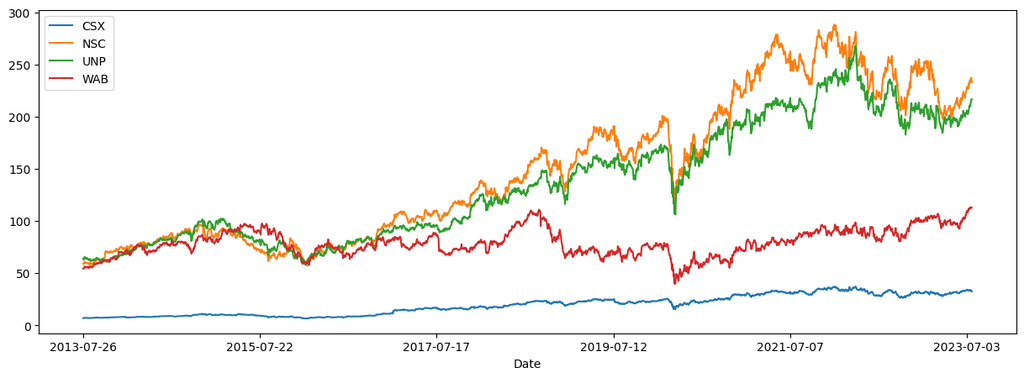

```python
# Collect Historical Data for each ticker
historical_data = rail_companies.get_historical_data()

# Show a portion of the dataset
display(historical_data.tail(5))

# Plot the Adjusted Close Prices
historical_data["Adj Close"].plot(figsize=(15, 5))
```

Let's have a look at the Balance Sheet Statement as well.

```python
# Collect and show the Balance Sheet Statements
rail_companies.get_balance_sheet_statement()
```

|  | date | 1985 | 1986 | 1987 | 1988 | 1989 | 1990 | 1991 | 1992 | 1993 | 1994 | ... | 2013 | 2014 | 2015 | 2016 | 2017 | 2018 | 2019 | 2020 | 2021 | 2022 |
| --- | --- | --- | --- | --- | --- | --- | --- | --- | --- | --- | --- | --- | --- | --- | --- | --- | --- | --- | --- | --- | --- | --- |
| CSX | Cash and Cash Equivalents | 1.870000e+08 | 3.150000e+08 | 921000000.0 | 625000000.0 | 534000000.0 | 609000000.0 | 465000000.0 | 530000000.0 | 298000000.0 | 535000000.0 | ... | 5.920000e+08 | 6.690000e+08 | 6.280000e+08 | 6.030000e+08 | 4.010000e+08 | 8.580000e+08 | 9.580000e+08 | 3.129000e+09 | 2.239000e+09 | 1.958000e+09 |
|  | Short Term Investments | 0.000000e+00 | 0.000000e+00 | 0.0 | 0.0 | 0.0 | 0.0 | 0.0 | 0.0 | 0.0 | 0.0 | ... | 4.870000e+08 | 2.920000e+08 | 8.100000e+08 | 4.170000e+08 | 1.800000e+07 | 2.530000e+08 | 9.960000e+08 | 2.000000e+06 | 7.700000e+07 | 1.290000e+08 |
|  | Cash and Short Term Investments | 1.870000e+08 | 3.150000e+08 | 921000000.0 | 625000000.0 | 534000000.0 | 609000000.0 | 465000000.0 | 530000000.0 | 298000000.0 | 535000000.0 | ... | 1.079000e+09 | 9.610000e+08 | 1.438000e+09 | 1.020000e+09 | 4.190000e+08 | 1.111000e+09 | 1.954000e+09 | 3.131000e+09 | 2.316000e+09 | 2.087000e+09 |
|  | Accounts Receivable | 1.299000e+09 | 1.182000e+09 | 876000000.0 | 896000000.0 | 645000000.0 | 728000000.0 | 728000000.0 | 605000000.0 | 668000000.0 | 706000000.0 | ... | 1.052000e+09 | 1.129000e+09 | 9.820000e+08 | 9.380000e+08 | 9.700000e+08 | 1.010000e+09 | 9.860000e+08 | 9.120000e+08 | 1.148000e+09 | 1.313000e+09 |
|  | Inventory | 4.280000e+08 | 3.560000e+08 | 363000000.0 | 241000000.0 | 237000000.0 | 257000000.0 | 206000000.0 | 189000000.0 | 199000000.0 | 211000000.0 | ... | 2.520000e+08 | 2.730000e+08 | 3.500000e+08 | 4.070000e+08 | 3.720000e+08 | 2.630000e+08 | 2.610000e+08 | 3.020000e+08 | 3.390000e+08 | 3.410000e+08 |
| ... | ... | ... | ... | ... | ... | ... | ... | ... | ... | ... | ... | ... | ... | ... | ... | ... | ... | ... | ... | ... | ... | ... |
| WAB | Minority Interest | NaN | NaN | NaN | NaN | NaN | NaN | NaN | NaN | NaN | NaN | ... | 1.908000e+06 | 1.056000e+06 | 1.732000e+06 | 7.708480e+08 | 1.966400e+07 | 3.944000e+06 | 3.710000e+07 | 3.040000e+07 | 3.800000e+07 | 4.500000e+07 |
|  | Total Liabilities and Equity | NaN | NaN | NaN | NaN | NaN | NaN | NaN | NaN | NaN | NaN | ... | 2.820089e+09 | 3.302785e+09 | 3.298603e+09 | 5.810170e+09 | 6.560316e+09 | 8.645290e+09 | 1.888620e+10 | 1.845450e+10 | 1.845400e+10 | 1.851600e+10 |
|  | Total Investments | NaN | NaN | NaN | NaN | NaN | NaN | NaN | NaN | NaN | NaN | ... | 0.000000e+00 | 0.000000e+00 | 0.000000e+00 | 0.000000e+00 | 0.000000e+00 | 0.000000e+00 | 0.000000e+00 | 0.000000e+00 | 0.000000e+00 | 0.000000e+00 |
|  | Total Debt | NaN | NaN | NaN | NaN | NaN | NaN | NaN | NaN | NaN | NaN | ... | 4.507090e+08 | 5.211950e+08 | 6.957270e+08 | 1.892776e+09 | 1.870528e+09 | 3.856873e+09 | 4.333600e+09 | 3.792200e+09 | 4.056000e+09 | 4.002000e+09 |
|  | Net Debt | NaN | NaN | NaN | NaN | NaN | NaN | NaN | NaN | NaN | NaN | ... | 1.649490e+08 | 9.534600e+07 | 4.695360e+08 | 1.494292e+09 | 1.637127e+09 | 3.275965e+09 | 3.729400e+09 | 3.193500e+09 | 3.583000e+09 | 3.461000e+09 |

172 rows × 38 columns

A very important financial ratio is the "Operating Ratio" for railroad companies. An operating ratio of 80 or lower has generally been seen as good but having a target as low as the mid-70s is even better. From the table below, it is clear that all companies except for WAB (Westinghouse Air Brake Technologies Corporation) are performing very well. This, however, makes sense since WAB is specialized on providing parts instead of actual railroad services.

```python
# Collect and show the Balance Sheet Statements
rail_companies.ratios.get_operating_ratio()
```

```
The following data was not provided within the Toolkit class and thus was retrieved from FinancialModelingPrep: Income Statement, Cash Flow Statement.
```

| date | 1985 | 1986 | 1987 | 1988 | 1989 | 1990 | 1991 | 1992 | 1993 | 1994 | ... | 2013 | 2014 | 2015 | 2016 | 2017 | 2018 | 2019 | 2020 | 2021 | 2022 |
| --- | --- | --- | --- | --- | --- | --- | --- | --- | --- | --- | --- | --- | --- | --- | --- | --- | --- | --- | --- | --- | --- |
| CSX | 0.879645 | 0.836564 | 0.888723 | 0.880269 | 0.887799 | 0.900670 | 0.988536 | 0.969544 | 0.897875 | 1.578684 | ... | 0.711209 | 0.714816 | 0.696554 | 0.693830 | 0.669267 | 0.610367 | 0.599062 | 0.589625 | 0.595831 | 0.619471 |
| NSC | 0.812031 | 0.827789 | 0.974470 | 0.788148 | 0.818078 | 0.824973 | 0.974839 | 0.807559 | 0.807090 | 0.897082 | ... | 0.703779 | 0.682037 | 0.714014 | 0.677488 | 0.647806 | 0.633793 | 0.646866 | 0.653999 | 0.600880 | 0.622676 |
| UNP | 0.845345 | 0.664131 | 0.612485 | 0.754120 | 0.775416 | 0.770103 | 0.766112 | 0.776392 | 0.816162 | 0.789433 | ... | 0.660975 | 0.635109 | 0.630862 | 0.635324 | 0.620480 | 0.626971 | 0.605952 | 0.598935 | 0.571730 | 0.601327 |
| WAB | NaN | NaN | NaN | NaN | NaN | NaN | NaN | NaN | 0.781633 | 0.743309 | ... | 0.829601 | 0.826863 | 0.816334 | 0.843626 | 0.891355 | 0.891502 | 0.919134 | 0.901470 | 0.888008 | 0.879096 |

4 rows × 38 columns

Other than this ratio, important other metrics are revenue growth, strong profit margins and efficient capital management. These can be explored further by looking into the income statement, the profit margin ratio and the current ratio.

```python
# Obtain the income statement and select the revenues
revenues = rail_companies.get_income_statement().loc[:, "Revenue", :]

# Show revenue absolute numbers for each company
display(revenues)

# Show the revenue growth for each company
display(revenues.pct_change(axis=1))
```

| date | 1985 | 1986 | 1987 | 1988 | 1989 | 1990 | 1991 | 1992 | 1993 | 1994 | ... | 2013 | 2014 | 2015 | 2016 | 2017 | 2018 | 2019 | 2020 | 2021 | 2022 |
| --- | --- | --- | --- | --- | --- | --- | --- | --- | --- | --- | --- | --- | --- | --- | --- | --- | --- | --- | --- | --- | --- |
| CSX | 7.320000e+09 | 6.345000e+09 | 8.043000e+09 | 7.592000e+09 | 7.745000e+09 | 8.205000e+09 | 8.636000e+09 | 8.734000e+09 | 8.940000e+09 | 9.608000e+09 | ... | 1.202600e+10 | 1.266900e+10 | 1.181100e+10 | 1.106900e+10 | 1.140800e+10 | 1.225000e+10 | 1.193700e+10 | 1.058300e+10 | 1.252200e+10 | 1.485300e+10 |
| NSC | 3.825100e+09 | 4.076400e+09 | 4.112800e+09 | 4.461600e+09 | 4.536000e+09 | 4.617000e+09 | 4.451300e+09 | 4.606600e+09 | 4.460100e+09 | 4.581300e+09 | ... | 1.124500e+10 | 1.162400e+10 | 1.051100e+10 | 9.888000e+09 | 1.055100e+10 | 1.145800e+10 | 1.129600e+10 | 9.789000e+09 | 1.114200e+10 | 1.274500e+10 |
| UNP | 7.798000e+09 | 6.574000e+09 | 5.943000e+09 | 6.068000e+09 | 6.492000e+09 | 6.964000e+09 | 7.029000e+09 | 7.294000e+09 | 7.561000e+09 | 7.798000e+09 | ... | 2.196300e+10 | 2.398800e+10 | 2.181300e+10 | 1.994100e+10 | 2.124000e+10 | 2.283200e+10 | 2.170800e+10 | 1.953300e+10 | 2.180400e+10 | 2.487500e+10 |
| WAB | NaN | NaN | NaN | NaN | NaN | NaN | NaN | NaN | 2.853000e+08 | 3.475000e+08 | ... | 2.566392e+09 | 3.044454e+09 | 3.307998e+09 | 2.931188e+09 | 3.881756e+09 | 4.363547e+09 | 8.200000e+09 | 7.556100e+09 | 7.822000e+09 | 8.362000e+09 |

4 rows × 38 columns

| date | 1985 | 1986 | 1987 | 1988 | 1989 | 1990 | 1991 | 1992 | 1993 | 1994 | ... | 2013 | 2014 | 2015 | 2016 | 2017 | 2018 | 2019 | 2020 | 2021 | 2022 |
| --- | --- | --- | --- | --- | --- | --- | --- | --- | --- | --- | --- | --- | --- | --- | --- | --- | --- | --- | --- | --- | --- |
| CSX | NaN | -0.133197 | 0.267612 | -0.056074 | 0.020153 | 0.059393 | 0.052529 | 0.011348 | 0.023586 | 0.074720 | ... | 0.022967 | 0.053467 | -0.067724 | -0.062823 | 0.030626 | 0.073808 | -0.025551 | -0.113429 | 0.183218 | 0.186152 |
| NSC | NaN | 0.065698 | 0.008929 | 0.084808 | 0.016676 | 0.017857 | -0.035889 | 0.034889 | -0.031802 | 0.027174 | ... | 0.018569 | 0.033704 | -0.095750 | -0.059271 | 0.067051 | 0.085963 | -0.014139 | -0.133410 | 0.138216 | 0.143870 |
| UNP | NaN | -0.156963 | -0.095984 | 0.021033 | 0.069875 | 0.072705 | 0.009334 | 0.037701 | 0.036605 | 0.031345 | ... | 0.049556 | 0.092201 | -0.090670 | -0.085820 | 0.065142 | 0.074953 | -0.049229 | -0.100193 | 0.116265 | 0.140846 |
| WAB | NaN | NaN | NaN | NaN | NaN | NaN | NaN | NaN | NaN | 0.218016 | ... | 0.073300 | 0.186278 | 0.086565 | -0.113909 | 0.324294 | 0.124117 | 0.879205 | -0.078524 | 0.035190 | 0.069036 |

4 rows × 38 columns

Profit Margins can be looked at from a variety of perspectives. The Finance Toolkit features Gross, Operating, Net Profit and EBT Profit Margins. With the `collect_profitability_ratios` functions within the `ratios` module these can be collected for each company accompanied with many other useful ratios. To provide an appropriate overview, the profitability ratios are only shown for `CSX`.

```python
# Collect the profitability ratios and select the ratios for CSX
rail_companies.ratios.collect_profitability_ratios().loc["CSX"]
```

| date | 1985 | 1986 | 1987 | 1988 | 1989 | 1990 | 1991 | 1992 | 1993 | 1994 | ... | 2013 | 2014 | 2015 | 2016 | 2017 | 2018 | 2019 | 2020 | 2021 | 2022 |
| --- | --- | --- | --- | --- | --- | --- | --- | --- | --- | --- | --- | --- | --- | --- | --- | --- | --- | --- | --- | --- | --- |
| Gross Margin | 0.176230 | 0.217652 | 0.178913 | 0.181243 | 0.169916 | 0.156977 | 0.069477 | 0.090795 | 0.166107 | 0.409971 | ... | 0.288791 | 0.285184 | 0.303446 | 0.306170 | 0.330733 | 0.389633 | 0.408310 | 0.412170 | 0.410478 | 0.389484 |
| Operating Margin | 0.120355 | 0.163436 | 0.111277 | 0.119731 | 0.112201 | 0.099330 | 0.011464 | 0.030456 | 0.102125 | 0.128226 | ... | 0.288791 | 0.285184 | 0.303446 | 0.306170 | 0.321441 | 0.397469 | 0.415934 | 0.412170 | 0.446734 | 0.405507 |
| Net Profit Margin | -0.016120 | 0.065879 | 0.053711 | -0.004347 | 0.055391 | 0.044363 | -0.008800 | 0.002290 | 0.040157 | 0.067860 | ... | 0.154998 | 0.152104 | 0.166624 | 0.154847 | 0.479576 | 0.270122 | 0.279048 | 0.261268 | 0.301949 | 0.280482 |
| Interest Coverage Ratio | inf | inf | inf | inf | inf | inf | -inf | -inf | inf | inf | ... | 8.144128 | 8.741284 | 8.808824 | 8.100173 | 9.124542 | 9.702660 | 8.686567 | 7.644562 | 9.195291 | 9.997305 |
| Income Before Tax Profit Margin | -0.035929 | 0.114894 | 0.084794 | -0.007903 | 0.089348 | 0.065448 | -0.013085 | -0.000801 | 0.070805 | 0.104704 | ... | 0.242974 | 0.240272 | 0.265685 | 0.247629 | 0.275421 | 0.351347 | 0.361565 | 0.342719 | 0.395384 | 0.364505 |
| Effective Tax Rate | 0.551331 | 0.426612 | 0.366569 | 0.366667 | 0.382948 | 0.320298 | 0.327434 | 3.857143 | 0.432859 | 0.351889 | ... | 0.362081 | 0.366951 | 0.372849 | 0.374681 | -0.741248 | 0.231180 | 0.228221 | 0.237662 | 0.236316 | 0.230513 |
| Return on Assets (ROA) | -0.010266 | 0.033015 | 0.032651 | -0.002533 | 0.034884 | 0.028429 | -0.005938 | 0.001533 | 0.026751 | 0.047508 | ... | 0.058650 | 0.058300 | 0.056166 | 0.048399 | 0.153082 | 0.090092 | 0.087069 | 0.069485 | 0.093287 | 0.099399 |
| Return on Equity (ROE) | NaN | 0.088297 | 0.088788 | -0.008148 | 0.126867 | 0.103087 | -0.022609 | 0.006497 | 0.116653 | 0.188685 | ... | 0.191464 | 0.178137 | 0.172601 | 0.146929 | 0.414721 | 0.242702 | 0.272742 | 0.221439 | 0.284179 | 0.318928 |
| Return on Invested Capital (ROIC) | NaN | NaN | NaN | NaN | 0.052769 | 0.050170 | 0.007164 | -0.078600 | 0.044786 | 0.082721 | ... | 0.078443 | 0.077442 | 0.074456 | 0.065167 | 0.405792 | 0.114254 | 0.112440 | 0.091077 | 0.118135 | 0.125890 |
| Return on Capital Employed (ROCE) | -0.027562 | 0.067413 | 0.060178 | -0.005519 | 0.069630 | 0.051043 | -0.010949 | -0.000650 | 0.056797 | 0.089669 | ... | 0.118673 | 0.115976 | 0.111282 | 0.099479 | 0.108967 | 0.141983 | 0.139949 | 0.115979 | 0.148128 | 0.156081 |
| Return on Tangible Assets | -0.025680 | 0.085779 | 0.088925 | -0.010179 | 0.121840 | 0.102796 | -0.023884 | 0.006723 | 0.112893 | 0.174752 | ... | 0.177456 | 0.172423 | 0.168666 | 0.146571 | 0.371646 | 0.263037 | 0.280789 | 0.210908 | 0.283752 | 0.334834 |
| Income Quality Ratio | NaN | NaN | NaN | NaN | 2.347319 | 2.442308 | -11.394737 | 46.950000 | 2.679666 | 2.033742 | ... | 1.752682 | 1.734821 | 1.712398 | 1.774212 | 0.634619 | 1.402539 | 1.456019 | 1.541772 | 1.348585 | 1.348776 |
| Net Income per EBT | 0.448669 | 0.573388 | 0.633431 | 0.600000 | 0.618156 | 0.679104 | 0.672566 | -2.857143 | 0.567141 | 0.648111 | ... | 0.637919 | 0.633049 | 0.627151 | 0.625319 | 1.741248 | 0.768820 | 0.771779 | 0.762338 | 0.763684 | 0.769487 |
| Free Cash Flow to Operating Cash Flow Ratio | NaN | NaN | NaN | NaN | 0.180735 | -0.042745 | 0.002309 | -0.108626 | 0.201663 | 0.340121 | ... | 0.292011 | 0.267424 | 0.239763 | 0.211444 | 0.412442 | 0.624003 | 0.658351 | 0.618578 | 0.648755 | 0.620395 |
| EBT to EBIT Ratio | 1.000000 | 1.000000 | 1.000000 | 1.000000 | 1.000000 | 1.000000 | 1.000000 | 1.000000 | 1.000000 | 1.000000 | ... | 0.838691 | 0.848147 | 0.852254 | 0.825602 | 0.851952 | 0.870726 | 0.854146 | 0.827893 | 0.872730 | 0.879467 |
| EBIT to Revenue | -0.035929 | 0.114894 | 0.084794 | -0.007244 | 0.089606 | 0.065326 | -0.013085 | -0.000801 | 0.070805 | 0.104704 | ... | 0.289706 | 0.283290 | 0.311743 | 0.299937 | 0.323282 | 0.403510 | 0.423306 | 0.413966 | 0.453043 | 0.414462 |

16 rows × 38 columns

Capital Management can be viewed from multiple angles including liquidity, accounts receivable, inventory and accounts payable management. These lead to the Operating and Cash Conversion Cycles. All of these ratios can be found within the `collect_efficiency_ratios` and `collect_liquidity_ratios` functions within the `ratios` module.

```python
# Collect the liquidity ratios for all companies
rail_companies.ratios.collect_liquidity_ratios()
```

|  | date | 1985 | 1986 | 1987 | 1988 | 1989 | 1990 | 1991 | 1992 | 1993 | 1994 | ... | 2013 | 2014 | 2015 | 2016 | 2017 | 2018 | 2019 | 2020 | 2021 | 2022 |
| --- | --- | --- | --- | --- | --- | --- | --- | --- | --- | --- | --- | --- | --- | --- | --- | --- | --- | --- | --- | --- | --- | --- |
| CSX | Current Ratio | 1.050205e+00 | 1.137520e+00 | 1.259220e+00 | 7.954917e-01 | 7.340197e-01 | 7.490230e-01 | 6.197013e-01 | 6.232456e-01 | 6.905495e-01 | 6.646707e-01 | ... | 1.073432e+00 | 1.220693e+00 | 1.519467e+00 | 1.219118e+00 | 1.011088e+00 | 1.339426e+00 | 1.523942e+00 | 2.199604e+00 | 1.734438e+00 | 1.557669e+00 |
|  | Quick Ratio | 7.612705e-01 | 8.105035e-01 | 9.467861e-01 | 4.968964e-01 | 5.057915e-01 | 5.805471e-01 | 4.816310e-01 | 4.978070e-01 | 4.246154e-01 | 4.954092e-01 | ... | 8.791254e-01 | 9.919317e-01 | 1.239754e+00 | 9.598039e-01 | 7.333685e-01 | 1.107572e+00 | 1.366806e+00 | 2.002476e+00 | 1.551276e+00 | 1.375961e+00 |
|  | Cash Ratio | 9.579918e-02 | 1.705468e-01 | 4.852476e-01 | 2.041816e-01 | 2.290862e-01 | 2.644377e-01 | 1.877271e-01 | 2.324561e-01 | 1.309890e-01 | 2.135729e-01 | ... | 4.451320e-01 | 4.560987e-01 | 7.366803e-01 | 5.000000e-01 | 2.212249e-01 | 5.801567e-01 | 9.084147e-01 | 1.550768e+00 | 1.037170e+00 | 8.445973e-01 |
|  | Working Capital | 9.800000e+07 | 2.540000e+08 | 4.920000e+08 | -6.260000e+08 | -6.200000e+08 | -5.780000e+08 | -9.420000e+08 | -8.590000e+08 | -7.040000e+08 | -8.400000e+08 | ... | 1.780000e+08 | 4.650000e+08 | 1.014000e+09 | 4.470000e+08 | 2.100000e+07 | 6.500000e+08 | 1.127000e+09 | 2.422000e+09 | 1.640000e+09 | 1.378000e+09 |
|  | Operating Cash Flow Ratio | NaN | NaN | NaN | NaN | 4.320034e-01 | 3.860182e-01 | 3.496165e-01 | 4.118421e-01 | 4.228571e-01 | 5.293413e-01 | ... | 1.347772e+00 | 1.586616e+00 | 1.726434e+00 | 1.490686e+00 | 1.833157e+00 | 2.423499e+00 | 2.254765e+00 | 2.111441e+00 | 2.283475e+00 | 2.273978e+00 |
|  | Operating Cash Flow to Sales Ratio | NaN | NaN | NaN | NaN | 1.300194e-01 | 1.083486e-01 | 1.002779e-01 | 1.075109e-01 | 1.076063e-01 | 1.380100e-01 | ... | 2.716614e-01 | 2.638724e-01 | 2.853272e-01 | 2.747312e-01 | 3.043478e-01 | 3.788571e-01 | 4.062997e-01 | 4.028158e-01 | 4.072033e-01 | 3.783074e-01 |
|  | Short Term Coverage Ratio | NaN | NaN | NaN | NaN | -1.022335e+00 | -9.250780e-01 | -7.563319e-01 | -7.382075e-01 | -8.761384e-01 | -1.233488e+00 | ... | 9.414986e+00 | 6.001795e+00 | 5.933099e+00 | 5.641929e+00 | 7.014141e+00 | 1.432407e+01 | 2.377451e+01 | 1.052593e+01 | 9.730916e+00 | 1.072328e+01 |
| NSC | Current Ratio | NaN | NaN | NaN | NaN | NaN | NaN | NaN | NaN | NaN | 1.181746e+00 | ... | 1.334056e+00 | 1.560674e+00 | 1.180188e+00 | 9.794784e-01 | 8.444008e-01 | 7.186415e-01 | 9.047826e-01 | 1.073148e+00 | 8.595795e-01 | 7.576444e-01 |
|  | Quick Ratio | NaN | NaN | NaN | NaN | NaN | NaN | NaN | NaN | NaN | 9.129705e-01 | ... | 1.121475e+00 | 1.139326e+00 | 9.175258e-01 | 8.127405e-01 | 6.463654e-01 | 5.275955e-01 | 6.521739e-01 | 9.087963e-01 | 7.199524e-01 | 6.055115e-01 |
|  | Cash Ratio | NaN | NaN | NaN | NaN | NaN | NaN | NaN | NaN | NaN | 2.709843e-01 | ... | 6.772234e-01 | 5.466292e-01 | 4.935007e-01 | 4.087217e-01 | 2.711198e-01 | 1.381706e-01 | 2.521739e-01 | 5.162037e-01 | 3.328044e-01 | 1.721404e-01 |
|  | Working Capital | NaN | NaN | NaN | NaN | NaN | NaN | NaN | NaN | NaN | 2.057000e+08 | ... | 7.700000e+08 | 9.980000e+08 | 4.020000e+08 | -4.800000e+07 | -3.960000e+08 | -7.290000e+08 | -2.190000e+08 | 1.580000e+08 | -3.540000e+08 | -6.420000e+08 |
|  | Operating Cash Flow Ratio | NaN | NaN | NaN | NaN | NaN | NaN | NaN | NaN | NaN | 1.011044e+00 | ... | 1.335358e+00 | 1.602247e+00 | 1.289556e+00 | 1.297136e+00 | 1.278193e+00 | 1.438055e+00 | 1.692174e+00 | 1.683796e+00 | 1.687822e+00 | 1.593809e+00 |
|  | Operating Cash Flow to Sales Ratio | NaN | NaN | NaN | NaN | 2.440917e-01 | 2.154429e-01 | 1.712758e-01 | 2.080059e-01 | 1.960943e-01 | 2.497763e-01 | ... | 2.737217e-01 | 2.453544e-01 | 2.737133e-01 | 3.068366e-01 | 3.083120e-01 | 3.251876e-01 | 3.445467e-01 | 3.715395e-01 | 3.818884e-01 | 3.312672e-01 |
|  | Short Term Coverage Ratio | NaN | NaN | NaN | NaN | NaN | NaN | NaN | NaN | NaN | 1.355806e+01 | ... | 5.476868e+00 | 5.252302e+00 | 4.678049e+00 | 5.496377e+00 | 9.163380e+00 | 9.603093e+00 | -1.474242e+01 | 6.862264e+01 | -2.710191e+01 | 3.909259e+01 |
| UNP | Current Ratio | 1.053667e+00 | 8.665550e-01 | 8.920128e-01 | 8.962366e-01 | 6.718415e-01 | 6.918412e-01 | 6.252677e-01 | 6.626679e-01 | 6.615606e-01 | 7.273453e-01 | ... | 1.052493e+00 | 1.242762e+00 | 1.288210e+00 | 9.879121e-01 | 1.017009e+00 | 8.999135e-01 | 7.949897e-01 | 1.009825e+00 | 6.182103e-01 | 7.159420e-01 |
|  | Quick Ratio | 7.221228e-01 | 5.209380e-01 | 5.629393e-01 | 6.188172e-01 | 3.549251e-01 | 3.936053e-01 | 3.533191e-01 | 3.934741e-01 | 3.657252e-01 | 4.231537e-01 | ... | 7.507254e-01 | 8.491368e-01 | 8.568309e-01 | 7.129121e-01 | 7.255649e-01 | 6.675313e-01 | 5.713629e-01 | 8.061347e-01 | 4.749304e-01 | 5.271739e-01 |
|  | Cash Ratio | 2.701252e-01 | 1.675042e-01 | 1.054313e-01 | 2.360215e-01 | 1.001071e-01 | 9.316428e-02 | 7.708779e-02 | 1.175624e-01 | 5.409287e-02 | 4.830339e-02 | ... | 3.777367e-01 | 4.212483e-01 | 4.338740e-01 | 3.673077e-01 | 3.465347e-01 | 2.881539e-01 | 2.047805e-01 | 4.454829e-01 | 1.751393e-01 | 1.846014e-01 |
|  | Working Capital | 9.000000e+07 | -2.390000e+08 | -1.690000e+08 | -1.930000e+08 | -6.130000e+08 | -5.590000e+08 | -7.000000e+08 | -7.030000e+08 | -7.070000e+08 | -6.830000e+08 | ... | 1.990000e+08 | 9.140000e+08 | 9.240000e+08 | -4.400000e+07 | 6.700000e+07 | -4.630000e+08 | -8.920000e+08 | 4.100000e+07 | -2.193000e+09 | -1.568000e+09 |
|  | Operating Cash Flow Ratio | NaN | NaN | NaN | NaN | 7.938972e-01 | 8.087100e-01 | 7.451820e-01 | 7.965451e-01 | 7.482049e-01 | 7.620758e-01 | ... | 1.799789e+00 | 1.961487e+00 | 2.290705e+00 | 2.067308e+00 | 1.835491e+00 | 1.877648e+00 | 1.978626e+00 | 2.046489e+00 | 1.572423e+00 | 1.696014e+00 |
|  | Operating Cash Flow to Sales Ratio | NaN | NaN | NaN | NaN | 2.284350e-01 | 2.106548e-01 | 1.980367e-01 | 2.275843e-01 | 2.067187e-01 | 2.448064e-01 | ... | 3.106588e-01 | 3.078623e-01 | 3.366800e-01 | 3.773632e-01 | 3.403955e-01 | 3.804310e-01 | 3.965819e-01 | 4.372088e-01 | 4.142359e-01 | 3.763618e-01 |
|  | Short Term Coverage Ratio | NaN | NaN | NaN | NaN | 3.975871e+00 | 3.296629e+00 | 4.046512e+00 | 5.608108e+00 | 3.669014e+00 | 2.413401e+00 | ... | 5.397943e+00 | 5.107192e+00 | 5.444033e+00 | 7.377451e+00 | 5.882832e+00 | 5.345231e+00 | 5.390733e+00 | 5.578054e+00 | 5.676933e+00 | 5.066017e+00 |
| WAB | Current Ratio | NaN | NaN | NaN | NaN | NaN | NaN | NaN | NaN | NaN | NaN | ... | 2.300737e+00 | 2.216919e+00 | 2.425551e+00 | 1.982271e+00 | 1.439694e+00 | 2.702189e+00 | 1.286710e+00 | 1.202554e+00 | 1.316838e+00 | 1.248053e+00 |
|  | Quick Ratio | NaN | NaN | NaN | NaN | NaN | NaN | NaN | NaN | NaN | NaN | ... | 1.450230e+00 | 1.430796e+00 | 1.240989e+00 | 9.269707e-01 | 8.899519e-01 | 1.049187e+00 | 6.961633e-01 | 6.233766e-01 | 6.701031e-01 | 5.941736e-01 |
|  | Cash Ratio | NaN | NaN | NaN | NaN | NaN | NaN | NaN | NaN | NaN | NaN | ... | 4.931999e-01 | 5.764048e-01 | 3.402515e-01 | 2.754550e-01 | 1.483484e-01 | 3.527731e-01 | 1.854512e-01 | 1.855686e-01 | 1.625430e-01 | 1.560427e-01 |
|  | Working Capital | NaN | NaN | NaN | NaN | NaN | NaN | NaN | NaN | NaN | NaN | ... | 7.536470e+08 | 8.990620e+08 | 9.476720e+08 | 1.420992e+09 | 6.917830e+08 | 2.802977e+09 | 9.341000e+08 | 6.535000e+08 | 9.220000e+08 | 8.600000e+08 |
|  | Operating Cash Flow Ratio | NaN | NaN | NaN | NaN | NaN | NaN | NaN | NaN | NaN | NaN | ... | 4.067190e-01 | 6.393932e-01 | 6.743023e-01 | 3.105868e-01 | 1.200072e-01 | 1.910930e-01 | 3.116943e-01 | 2.429098e-01 | 3.687285e-01 | 2.993943e-01 |
|  | Operating Cash Flow to Sales Ratio | NaN | NaN | NaN | NaN | NaN | NaN | NaN | NaN | 1.296880e-01 | 1.257554e-01 | ... | 9.182268e-02 | 1.551625e-01 | 1.355079e-01 | 1.532849e-01 | 4.864062e-02 | 7.211358e-02 | 1.238415e-01 | 1.037175e-01 | 1.371772e-01 | 1.241330e-01 |
|  | Short Term Coverage Ratio | NaN | NaN | NaN | NaN | NaN | NaN | NaN | NaN | NaN | NaN | ... | 3.734205e-01 | 6.363545e-01 | 5.914984e-01 | 4.195966e-01 | 1.391492e-01 | 2.244100e-01 | 4.454924e-01 | 3.653272e-01 | 4.981430e-01 | 4.609236e-01 |

28 rows × 38 columns

```python
# Collect the efficiency ratios for all companies
rail_companies.ratios.collect_efficiency_ratios()
```

|  | date | 1985 | 1986 | 1987 | 1988 | 1989 | 1990 | 1991 | 1992 | 1993 | 1994 | ... | 2013 | 2014 | 2015 | 2016 | 2017 | 2018 | 2019 | 2020 | 2021 | 2022 |
| --- | --- | --- | --- | --- | --- | --- | --- | --- | --- | --- | --- | --- | --- | --- | --- | --- | --- | --- | --- | --- | --- | --- |
| CSX | Days of Inventory Outstanding (DIO) | NaN | 28.823529 | 19.869397 | 17.733269 | 13.568984 | 13.033830 | 10.514871 | 9.077887 | 9.498323 | 13.198977 | ... | 11.223547 | 10.580002 | 13.820044 | 17.988607 | 18.620498 | 15.499198 | 13.539572 | 16.516235 | 15.846993 | 13.685487 |
|  | Days of Sales Outstanding (DSO) | NaN | 71.360520 | 46.697128 | 42.596154 | 36.311491 | 30.539001 | 30.768874 | 27.853504 | 25.986857 | 26.098564 | ... | 30.563363 | 31.417831 | 32.618534 | 31.655976 | 30.523317 | 29.497959 | 30.516043 | 32.730322 | 30.023159 | 30.238504 |
|  | Operating Cycle (CC) | NaN | 100.184050 | 66.566525 | 60.329423 | 49.880476 | 43.572830 | 41.283745 | 36.931390 | 35.485180 | 39.297541 | ... | 41.786910 | 41.997833 | 46.438577 | 49.644583 | 49.143815 | 44.997157 | 44.055615 | 49.246558 | 45.870152 | 43.923991 |
|  | Days of Accounts Payable Outstanding (DPO) | NaN | 0.000000 | 0.000000 | 0.000000 | 52.998522 | 100.603224 | 91.408972 | 95.260358 | 98.679745 | 127.386223 | ... | 42.056296 | 36.314598 | 35.692537 | 37.307943 | 39.511788 | 43.837100 | 51.471046 | 54.330493 | 43.807911 | 42.123125 |
|  | Cash Conversion Cycle (CCC) | NaN | 100.184050 | 66.566525 | 60.329423 | -3.118047 | -57.030394 | -50.125227 | -58.328967 | -63.194565 | -88.088683 | ... | -0.269386 | 5.683235 | 10.746041 | 12.336640 | 9.632027 | 1.160056 | -7.415431 | -5.083936 | 2.062241 | 1.800866 |
|  | Receivables Turnover | NaN | 0.195508 | 0.127937 | 0.116702 | 0.099484 | 0.083668 | 0.084298 | 0.076311 | 0.071197 | 0.071503 | ... | 0.083735 | 0.086076 | 0.089366 | 0.086729 | 0.083626 | 0.080816 | 0.083606 | 0.089672 | 0.082255 | 0.082845 |
|  | Inventory Turnover Ratio | NaN | 12.663265 | 18.369958 | 20.582781 | 26.899582 | 28.004049 | 34.712743 | 40.207595 | 38.427835 | 27.653659 | ... | 32.520913 | 34.499048 | 26.410915 | 20.290621 | 19.602054 | 23.549606 | 26.958015 | 22.099467 | 23.032761 | 26.670588 |
|  | Accounts Payable Turnover Ratio | NaN | inf | inf | inf | 6.886984 | 3.628114 | 3.993043 | 3.831604 | 3.698834 | 2.865302 | ... | 8.678843 | 10.051054 | 10.226227 | 9.783439 | 9.237750 | 8.326281 | 7.091365 | 6.718143 | 8.331828 | 8.665074 |
|  | SGA-to-Revenue Ratio | 0.000000 | 0.000000 | 0.000000 | 0.000000 | 0.000000 | 0.000000 | 0.000000 | 0.000000 | 0.000000 | 0.446503 | ... | 0.000000 | 0.000000 | 0.000000 | 0.000000 | 0.000000 | 0.000000 | 0.000000 | 0.000000 | 0.000000 | 0.000000 |
|  | Fixed Asset Turnover | NaN | 0.634373 | 0.751647 | 0.708473 | 0.731419 | 0.757408 | 0.773073 | 0.763095 | 0.761596 | 0.803748 | ... | 0.422335 | 0.424700 | 0.377626 | 0.340585 | 0.341808 | 0.360358 | 0.345284 | 0.300948 | 0.347785 | 0.397559 |
|  | Asset Turnover Ratio | NaN | 0.525357 | 0.621273 | 0.578284 | 0.611673 | 0.653733 | 0.674635 | 0.675823 | 0.675507 | 0.707928 | ... | 0.385739 | 0.390807 | 0.346913 | 0.314224 | 0.320661 | 0.338080 | 0.318379 | 0.271185 | 0.311787 | 0.360322 |
|  | Operating Ratio | 0.879645 | 0.836564 | 0.888723 | 0.880269 | 0.887799 | 0.900670 | 0.988536 | 0.969544 | 0.897875 | 1.578684 | ... | 0.711209 | 0.714816 | 0.696554 | 0.693830 | 0.669267 | 0.610367 | 0.599062 | 0.589625 | 0.595831 | 0.619471 |
| NSC | Days of Inventory Outstanding (DIO) | NaN | NaN | NaN | NaN | NaN | NaN | NaN | NaN | NaN | NaN | ... | 10.566803 | 11.052579 | 12.995435 | 15.105816 | 13.301506 | 10.864904 | 12.533501 | 14.761263 | 13.031474 | 11.900526 |
|  | Days of Sales Outstanding (DSO) | NaN | NaN | NaN | NaN | NaN | NaN | NaN | NaN | NaN | NaN | ... | 34.617386 | 32.640872 | 34.742888 | 34.901648 | 32.864183 | 31.282074 | 31.165235 | 32.961487 | 29.876144 | 30.414280 |
|  | Operating Cycle (CC) | NaN | NaN | NaN | NaN | NaN | NaN | NaN | NaN | NaN | NaN | ... | 45.184188 | 43.693452 | 47.738324 | 50.007464 | 46.165690 | 42.146978 | 43.698736 | 47.722750 | 42.907618 | 42.314806 |
|  | Days of Accounts Payable Outstanding (DPO) | NaN | NaN | NaN | NaN | NaN | NaN | NaN | NaN | NaN | NaN | ... | 35.190583 | 34.506201 | 34.603230 | 35.819094 | 40.876446 | 41.788093 | 62.695295 | 77.583928 | 70.263094 | 66.804652 |
|  | Cash Conversion Cycle (CCC) | NaN | NaN | NaN | NaN | NaN | NaN | NaN | NaN | NaN | NaN | ... | 9.993605 | 9.187250 | 13.135093 | 14.188371 | 5.289244 | 0.358885 | -18.996558 | -29.861177 | -27.355476 | -24.489846 |
|  | Receivables Turnover | NaN | NaN | NaN | NaN | NaN | NaN | NaN | NaN | NaN | NaN | ... | 0.094842 | 0.089427 | 0.095186 | 0.095621 | 0.090039 | 0.085704 | 0.085384 | 0.090305 | 0.081852 | 0.083327 |
|  | Inventory Turnover Ratio | NaN | NaN | NaN | NaN | NaN | NaN | NaN | NaN | NaN | NaN | ... | 34.542141 | 33.023965 | 28.086785 | 24.162879 | 27.440501 | 33.594406 | 29.121951 | 24.726882 | 28.009112 | 30.670913 |
|  | Accounts Payable Turnover Ratio | NaN | NaN | NaN | NaN | NaN | NaN | NaN | NaN | NaN | NaN | ... | 10.372093 | 10.577809 | 10.548148 | 10.190096 | 8.929348 | 8.734545 | 5.821809 | 4.704583 | 5.194761 | 5.463691 |
|  | SGA-to-Revenue Ratio | 0.090873 | 0.096016 | 0.236773 | 0.264210 | 0.089793 | 0.089192 | 0.082965 | 0.325663 | 0.338468 | 0.358261 | ... | 0.005780 | 0.009549 | 0.013129 | 0.002023 | 0.000000 | -0.005324 | -0.005577 | -0.009296 | -0.009155 | 0.006042 |
|  | Fixed Asset Turnover | NaN | NaN | NaN | NaN | NaN | NaN | NaN | NaN | NaN | NaN | ... | 0.391076 | 0.388302 | 0.338573 | 0.307903 | 0.318940 | 0.337303 | 0.321736 | 0.273872 | 0.309629 | 0.348205 |
|  | Asset Turnover Ratio | NaN | NaN | NaN | NaN | NaN | NaN | NaN | NaN | NaN | NaN | ... | 0.357979 | 0.353722 | 0.311432 | 0.285979 | 0.298882 | 0.318499 | 0.304630 | 0.257996 | 0.291466 | 0.329422 |
|  | Operating Ratio | 0.812031 | 0.827789 | 0.974470 | 0.788148 | 0.818078 | 0.824973 | 0.974839 | 0.807559 | 0.807090 | 0.897082 | ... | 0.703779 | 0.682037 | 0.714014 | 0.677488 | 0.647806 | 0.633793 | 0.646866 | 0.653999 | 0.600880 | 0.622676 |
| UNP | Days of Inventory Outstanding (DIO) | NaN | 63.201675 | 89.308511 | 39.618570 | 45.863420 | 40.018454 | 36.610224 | 36.879879 | 34.976816 | 31.528793 | ... | 17.531643 | 17.407064 | 20.585807 | 22.718686 | 21.874336 | 20.469984 | 22.529560 | 24.482567 | 20.351417 | 18.183248 |
|  | Days of Sales Outstanding (DSO) | NaN | 38.615379 | 41.425627 | 42.948253 | 33.396488 | 26.756534 | 27.547660 | 27.297436 | 29.591985 | 37.211464 | ... | 22.809384 | 23.014111 | 24.823614 | 23.923324 | 23.637359 | 25.961808 | 28.163580 | 28.963805 | 27.010067 | 26.507437 |
|  | Operating Cycle (CC) | NaN | 101.817054 | 130.734137 | 82.566823 | 79.259908 | 66.774988 | 64.157884 | 64.177315 | 64.568801 | 68.740258 | ... | 40.341027 | 40.421176 | 45.409421 | 46.642010 | 45.511694 | 46.431792 | 50.693140 | 53.446372 | 47.361484 | 44.690685 |
|  | Days of Accounts Payable Outstanding (DPO) | NaN | 0.000000 | 0.000000 | 0.000000 | 31.644893 | 56.105080 | 58.025237 | 72.572637 | 70.517774 | 52.269957 | ... | 21.737635 | 21.424079 | 23.031082 | 26.549435 | 29.364729 | 25.879222 | 24.461096 | 23.989038 | 22.048716 | 20.506218 |
|  | Cash Conversion Cycle (CCC) | NaN | 101.817054 | 130.734137 | 82.566823 | 47.615015 | 10.669907 | 6.132647 | -8.395322 | -5.948973 | 16.470301 | ... | 18.603392 | 18.997096 | 22.378339 | 20.092575 | 16.146965 | 20.552570 | 26.232044 | 29.457334 | 25.312768 | 24.184467 |
|  | Receivables Turnover | NaN | 0.105796 | 0.113495 | 0.117666 | 0.091497 | 0.073306 | 0.075473 | 0.074787 | 0.081074 | 0.101949 | ... | 0.062491 | 0.063052 | 0.068010 | 0.065543 | 0.064760 | 0.071128 | 0.077160 | 0.079353 | 0.074000 | 0.072623 |
|  | Inventory Turnover Ratio | NaN | 5.775163 | 4.086957 | 9.212851 | 7.958412 | 9.120792 | 9.969892 | 9.896996 | 10.435484 | 11.576720 | ... | 20.819497 | 20.968498 | 17.730663 | 16.066070 | 16.686221 | 17.830986 | 16.200938 | 14.908567 | 17.934869 | 20.073421 |
|  | Accounts Payable Turnover Ratio | NaN | inf | inf | inf | 11.534247 | 6.505650 | 6.290366 | 5.029444 | 5.176000 | 6.982979 | ... | 16.791155 | 17.036905 | 15.848148 | 13.747939 | 12.429878 | 14.103979 | 14.921653 | 15.215283 | 16.554252 | 17.799479 |
|  | SGA-to-Revenue Ratio | 0.288664 | 0.271068 | 0.364799 | 0.313942 | 0.380930 | 0.365451 | 0.358088 | 0.357280 | 0.348367 | 0.095537 | ... | 0.000000 | 0.000000 | 0.000000 | 0.000000 | 0.000000 | 0.000000 | 0.000000 | 0.000000 | 0.000000 | 0.000000 |
|  | Fixed Asset Turnover | NaN | 0.720280 | 0.631093 | 0.604262 | 0.596554 | 0.604855 | 0.586214 | 0.586452 | 0.574195 | 0.562241 | ... | 0.492003 | 0.511591 | 0.442872 | 0.388744 | 0.401050 | 0.419768 | 0.383540 | 0.335624 | 0.369065 | 0.409563 |
|  | Asset Turnover Ratio | NaN | 0.609466 | 0.545680 | 0.524301 | 0.525945 | 0.545405 | 0.532419 | 0.531943 | 0.519674 | 0.504024 | ... | 0.453388 | 0.468301 | 0.406519 | 0.361519 | 0.374194 | 0.390447 | 0.359344 | 0.314868 | 0.346307 | 0.385737 |
|  | Operating Ratio | 0.845345 | 0.664131 | 0.612485 | 0.754120 | 0.775416 | 0.770103 | 0.766112 | 0.776392 | 0.816162 | 0.789433 | ... | 0.660975 | 0.635109 | 0.630862 | 0.635324 | 0.620480 | 0.626971 | 0.605952 | 0.598935 | 0.571730 | 0.601327 |
| WAB | Days of Inventory Outstanding (DIO) | NaN | NaN | NaN | NaN | NaN | NaN | NaN | NaN | NaN | NaN | ... | 82.044375 | 79.127200 | 79.899737 | 103.399653 | 90.791392 | 92.573064 | 80.679238 | 115.016424 | 111.484641 | 116.703452 |
|  | Days of Sales Outstanding (DSO) | NaN | NaN | NaN | NaN | NaN | NaN | NaN | NaN | NaN | NaN | ... | 67.158986 | 71.078605 | 67.859091 | 95.963378 | 99.168092 | 96.762018 | 62.554724 | 74.303278 | 67.416741 | 65.387467 |
|  | Operating Cycle (CC) | NaN | NaN | NaN | NaN | NaN | NaN | NaN | NaN | NaN | NaN | ... | 149.203361 | 150.205804 | 147.758828 | 199.363031 | 189.959484 | 189.335082 | 143.233961 | 189.319702 | 178.901383 | 182.090920 |
|  | Days of Accounts Payable Outstanding (DPO) | NaN | NaN | NaN | NaN | NaN | NaN | NaN | NaN | NaN | NaN | ... | 58.248339 | 62.883575 | 58.086041 | 77.269936 | 70.159176 | 66.591937 | 53.836236 | 69.608646 | 64.305061 | 72.504723 |
|  | Cash Conversion Cycle (CCC) | NaN | NaN | NaN | NaN | NaN | NaN | NaN | NaN | NaN | NaN | ... | 90.955022 | 87.322229 | 89.672787 | 122.093095 | 119.800308 | 122.743145 | 89.397725 | 119.711056 | 114.596321 | 109.586196 |
|  | Receivables Turnover | NaN | NaN | NaN | NaN | NaN | NaN | NaN | NaN | NaN | NaN | ... | 0.183997 | 0.194736 | 0.185915 | 0.262913 | 0.271693 | 0.265101 | 0.171383 | 0.203571 | 0.184703 | 0.179144 |
|  | Inventory Turnover Ratio | NaN | NaN | NaN | NaN | NaN | NaN | NaN | NaN | NaN | NaN | ... | 4.448812 | 4.612826 | 4.568225 | 3.529993 | 4.020205 | 3.942832 | 4.524088 | 3.173460 | 3.273994 | 3.127585 |
|  | Accounts Payable Turnover Ratio | NaN | NaN | NaN | NaN | NaN | NaN | NaN | NaN | NaN | NaN | ... | 6.266273 | 5.804377 | 6.283782 | 4.723700 | 5.202456 | 5.481144 | 6.779820 | 5.243602 | 5.676070 | 5.034155 |
|  | SGA-to-Revenue Ratio | NaN | NaN | NaN | NaN | NaN | NaN | NaN | NaN | 0.094988 | 0.082878 | ... | 0.102369 | 0.106600 | 0.105010 | 0.126844 | 0.131873 | 0.145121 | 0.142268 | 0.125475 | 0.131680 | 0.123057 |
|  | Fixed Asset Turnover | NaN | NaN | NaN | NaN | NaN | NaN | NaN | NaN | NaN | NaN | ... | 1.868146 | 1.929972 | 1.972652 | 1.085369 | 0.967026 | 1.024979 | 0.868016 | 0.516325 | 0.535814 | 0.580473 |
|  | Asset Turnover Ratio | NaN | NaN | NaN | NaN | NaN | NaN | NaN | NaN | NaN | NaN | ... | 0.992127 | 0.993972 | 1.001791 | 0.593277 | 0.589888 | 0.573050 | 0.595596 | 0.404711 | 0.423859 | 0.452367 |
|  | Operating Ratio | NaN | NaN | NaN | NaN | NaN | NaN | NaN | NaN | 0.781633 | 0.743309 | ... | 0.829601 | 0.826863 | 0.816334 | 0.843626 | 0.891355 | 0.891502 | 0.919134 | 0.901470 | 0.888008 | 0.879096 |

48 rows × 38 columns